# Cluster Analysis - Part 2

WDI Indicators

Mohammadmahdi Faryabi - STD-ID: 93101951

2018-07-20 16:36:02

> با توجه به داده بانک جهانی به سوالات زیر پاسخ دهید. برای استفاده از داده از سه فایل زیر استفاده نمایید. داده نام کشورها: WDICountry داده نام سری های زمانی: WDISeries داده کل: WDIData در صورتی که داده را در اختیار ندارید می توانید از بسته WDI استفاده نموده و داده های مورد نظر را استخراج نمایید.

> gathering required data and loading required packages…

```r
library(WDI)
library(dplyr)
```

```r
library(readr)
library(highcharter)
library(tidyr)

country_series <- read_csv('../../WDI_csv/WDICountry-Series.csv')
country <- read_csv('../../WDI_csv/WDICountry.csv')
data <- read_csv('../../WDI_csv/WDIData.csv')
footnote <- read_csv('../../WDI_csv/WDIFootNote.csv')
series_time <- read_csv('../../WDI_csv/WDISeries-Time.csv')
series <- read_csv('../../WDI_csv/WDISeries.csv')
```

۵. رشد اقتصادی ایران را با کشورهای دیگر در طول ۲۰ سال گذشته بر حسب بیست شاخص های اقتصادی مهم مانند تولید ناخالص ملی، تورم و … ارزیابی کنید! (برای هر شاخص از تصویرسازی استفاده کنید.)

> required information is provided in separate plots.

```r
################################################################################
#### Q5


compare_iran_with_others <- function (indicator_code, indicator_name) {
  data %>% filter(`Indicator Code` == indicator_code) %>%
    gather(key = 'year', value = 'lexp', `1960`:`2016`) %>%
    select(`Country Name`, `Country Code`, year, lexp) %>% .[complete.cases(.),] -> all_country_data


  iran_data <- all_country_data %>% filter(`Country Code` == 'IRN')

  hcboxplot(x = all_country_data$lexp, var = all_country_data$year, outliers = FALSE) %>% hc_chart(type = "column") %>%
    hc_add_series(type = 'line', iran_data, color = 'red', hcaes(x = year, y = lexp)) %>%
    hc_yAxis(title = list(text = indicator_name)) %>%
    hc_xAxis(title = list(text = 'Year'))
}

compare_iran_with_others('NE.EXP.GNFS.ZS', 'Exports of goods and services (% of GDP)')
```

[interactive chart not shown]

```r
compare_iran_with_others('NE.IMP.GNFS.ZS', 'Imports of goods and services (% of GDP)')
```

[interactive chart not shown]

```r
compare_iran_with_others('FP.CPI.TOTL.ZG', 'Inflation, consumer prices (annual %)')
```

[interactive chart not shown]

```r
compare_iran_with_others('NY.GDP.DEFL.KD.ZG', 'Inflation, GDP deflator (annual %)')
```

[interactive chart not shown]

```r
compare_iran_with_others('MS.MIL.MPRT.KD', 'Arms imports (SIPRI trend indicator values)')
```

[interactive chart not shown]

```r
compare_iran_with_others('MS.MIL.XPRT.KD', 'Arms exports (SIPRI trend indicator values)')
```

[interactive chart not shown]

```r
compare_iran_with_others('TX.MNF.TECH.ZS.UN', 'Medium and high-tech exports (% manufactured exports)')
```

[interactive chart not shown]

```r
compare_iran_with_others('FI.RES.TOTL.CD', 'Total reserves (includes gold, current US$)')
```

[interactive chart not shown]

```r
compare_iran_with_others('GC.TAX.TOTL.GD.ZS', 'Tax revenue (% of GDP)')
```

[interactive chart not shown]

```r
compare_iran_with_others('GC.TAX.EXPT.ZS', 'Taxes on exports (% of tax revenue)')
```

[interactive chart not shown]

```r
compare_iran_with_others('BX.KLT.DINV.CD.WD', 'Foreign direct investment, net inflows (BoP, current US$)')
```

[interactive chart not shown]

```r
compare_iran_with_others('BX.KLT.DINV.WD.GD.ZS', 'Foreign direct investment, net inflows (% of GDP)')
```

[interactive chart not shown]

```r
compare_iran_with_others('NY.GDP.MKTP.KD', 'GDP (constant 2010 US$)')
```

[interactive chart not shown]

```r
compare_iran_with_others('NY.GDP.MKTP.KD.ZG', 'GDP growth (annual %)')
```

[interactive chart not shown]

```r
compare_iran_with_others('SI.POV.GAPS', 'Poverty gap at $1.90 a day (2011 PPP) (%)')
```

[interactive chart not shown]

```r
compare_iran_with_others('SI.POV.LMIC.GP', 'Poverty gap at $3.20 a day (2011 PPP) (%)')
```

[interactive chart not shown]

```r
compare_iran_with_others('SI.POV.UMIC.GP', 'Poverty gap at $5.50 a day (2011 PPP) (%)')
```

[interactive chart not shown]

```r
compare_iran_with_others('BN.CAB.XOKA.GD.ZS', 'Current account balance (% of GDP)')
```

[interactive chart not shown]

```r
compare_iran_with_others('NV.AGR.TOTL.ZS', 'Agriculture, value added (% of GDP)')
```

[interactive chart not shown]

```r
compare_iran_with_others('SH.XPD.CHEX.GD.ZS', 'Current health expenditure (% of GDP)')
```

[interactive chart not shown]

```r
compare_iran_with_others('SE.XPD.PRIM.PC.ZS', 'Government expenditure per student, primary (% of GDP per capita)')
```

[interactive chart not shown]

```r
compare_iran_with_others('NV.IND.TOTL.ZS', 'Industry, value added (% of GDP)')
```

[interactive chart not shown]

۶. در قسمت قبل با استفاده از روش خوشه بندی k-means داده ها را به سه دسته تقسیم کنید. ایران در کدام دسته می گنجد؟ (پیش از خوشه بندی طبیعتا داده را باید پاکسازی و استاندارد سازی نمایید.)

> Iran is in group 2 of countries with coutries like Indonesia, Jamaica, Iraq, Dominica, Brazil, Afghanistan, Argentina and Russian Federation.

```r
################################################################################
#### Q6

q5_series <- c('NE.EXP.GNFS.ZS', 'NE.IMP.GNFS.ZS', 'FP.CPI.TOTL.ZG', 'NY.GDP.DEFL.KD.ZG',
               'MS.MIL.MPRT.KD', 'MS.MIL.XPRT.KD', 'TX.MNF.TECH.ZS.UN', 'FI.RES.TOTL.CD',
               'GC.TAX.TOTL.GD.ZS', 'GC.TAX.EXPT.ZS', 'BX.KLT.DINV.CD.WD', 'BX.KLT.DINV.WD.GD',
               'NY.GDP.MKTP.KD', 'NY.GDP.MKTP.KD.ZG', 'SI.POV.GAPS', 'SI.POV.LMIC.GP',
               'SI.POV.UMIC.GP', 'BN.CAB.XOKA.GD.ZS', 'NV.AGR.TOTL.ZS', 'SH.XPD.CHEX.GD.ZS',
               'GC.DOD.TOTL.GD.ZS', 'SE.XPD.PRIM.PC.ZS', 'NV.IND.TOTL.ZS')

normalize <- function(column) {
  result <- (column - mean(column, na.rm = TRUE)) / sd(column, na.rm = TRUE)
  return(result)
}

data %>% select(-X63) %>% filter(`Indicator Code` %in% q5_series) %>%
  gather(key = 'year', value = 'value', `1960`:`2017`) %>%
  group_by(`Indicator Code`) %>% mutate(value = normalize(value)) %>%
  ungroup %>% group_by(`Country Name`, `Country Code`, `Indicator Code`) %>%
  summarise(mean_value = mean(value, na.rm = TRUE)) -> q6_data

q6_data %>% spread(key = `Indicator Code`, value = mean_value) -> q6_data

q6_data %>% select(-GC.DOD.TOTL.GD.ZS) %>% ungroup -> q6_data

# filling NAs with mean of the column

for (i in 1:ncol(q6_data)) {
  if ((q6_data[which(is.na(q6_data[i])),i] %>% nrow) > 0) {
    q6_data[which(is.na(q6_data[i])),i] <- q6_data[i] %>% na.omit %>% unlist %>% mean
  }
}

q6_data %>% select(BN.CAB.XOKA.GD.ZS:TX.MNF.TECH.ZS.UN) %>% kmeans(centers = 3) -> kmeans_data

cbind(
  q6_data %>% select(`Country Name`, `Country Code`),
  cluster = kmeans_data$cluster
  ) -> q6_table_data


library(knitr)

kable(q6_table_data %>% arrange(cluster))
```

| Country Name | Country Code | cluster |
| --- | --- | --- |
| Bangladesh | BGD | 1 |
| Benin | BEN | 1 |
| Burkina Faso | BFA | 1 |
| Burundi | BDI | 1 |
| Central African Republic | CAF | 1 |
| Chad | TCD | 1 |
| Congo, Dem. Rep. | COD | 1 |
| Ethiopia | ETH | 1 |
| Fragile and conflict affected situations | FCS | 1 |
| Gambia, The | GMB | 1 |
| Ghana | GHA | 1 |
| Guinea | GIN | 1 |
| Guinea-Bissau | GNB | 1 |
| IDA total | IDA | 1 |
| India | IND | 1 |
| Kenya | KEN | 1 |
| Lao PDR | LAO | 1 |
| Lesotho | LSO | 1 |
| Liberia | LBR | 1 |
| Low income | LIC | 1 |
| Madagascar | MDG | 1 |
| Malawi | MWI | 1 |
| Mali | MLI | 1 |
| Mozambique | MOZ | 1 |
| Nepal | NPL | 1 |
| Niger | NER | 1 |
| Nigeria | NGA | 1 |
| Papua New Guinea | PNG | 1 |
| Rwanda | RWA | 1 |
| Senegal | SEN | 1 |

[output cut: 234 more lines]

۷. به وسیله تحلیل مولفه اصلی بعد داده رو به دو کاهش دهید سپس خوشه های به دست آمده در قسمت قبل را بر روی آن نمایش دهید. آیا عملکرد روش خوشه بندی شما مطلوب بوده است؟

> The clustering performed by algorithem is close to what i would expect based of countries’ financial situations. so I think the algorithem has done well!

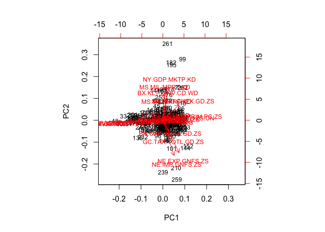

```r
################################################################################
#### Q7

all_data <- q6_data %>% select(-`Country Name`, -`Country Code`)
all_data %>% prcomp -> q7_pca
biplot(q7_pca, cex = 0.8)
```

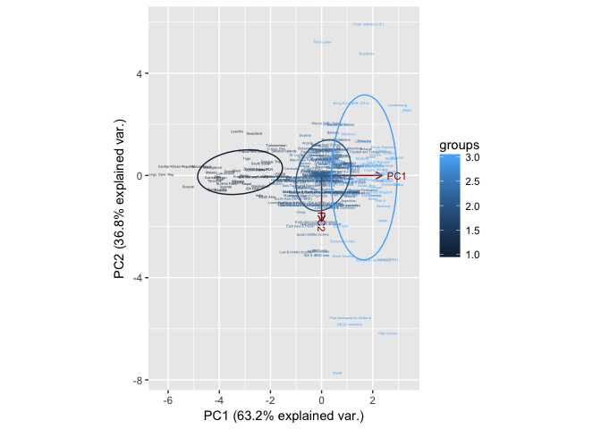

```r
chosen_components <- 1:2
compact_data <- q7_pca$x[,chosen_components]

# feature_vector <- q7_pca$rotation[,chosen_components]
# compact_data <- t(feature_vector) %*% t(all_data)
# compact_result <- t(feature_vector %*% compact_data)

library(ggbiplot)
compact_data %>% prcomp %>% ggbiplot(obs.scale = 1, var.scale = 1,
         groups = kmeans_data$cluster, ellipse = TRUE, labels = q6_data$`Country Name`, labels.size = 1)
```